# Reproducible Research - Assignment 1

Danny Cherian

April 3, 2016

## Loading and preprocessing the data

Check if the file exists. if not then download from the URL

```r
library(knitr)
library(dplyr)
library(lubridate)
```

```r
if(!file.exists("activity.csv")) {
  temp <- tempfile()
  download.file("https://d396qusza40orc.cloudfront.net/repdata%2Fdata%2Factivity.zip",temp)
  file <- unzip(temp)
  unlink(temp)
}else{
  file <- "./activity.csv"
}
```

Read the Data

```r
data <- read.csv(file, header=TRUE, stringsAsFactors=FALSE, colClasses = c("numeric", "character",
                                                                         "integer"))
data$date <- ymd(data$date)
```

## What is mean total number of steps taken per day?

For this part of the assignment the missing values can be ignored. Remove the NA values and use the dplyr package to group by date and calculate the daily sum of steps

```r
stepsbydate <- data %>%
  filter(!is.na(steps)) %>%
  group_by(date) %>%
  summarize(stepsdaily = sum(steps))
```

Make a histogram of the total number of steps taken each day.

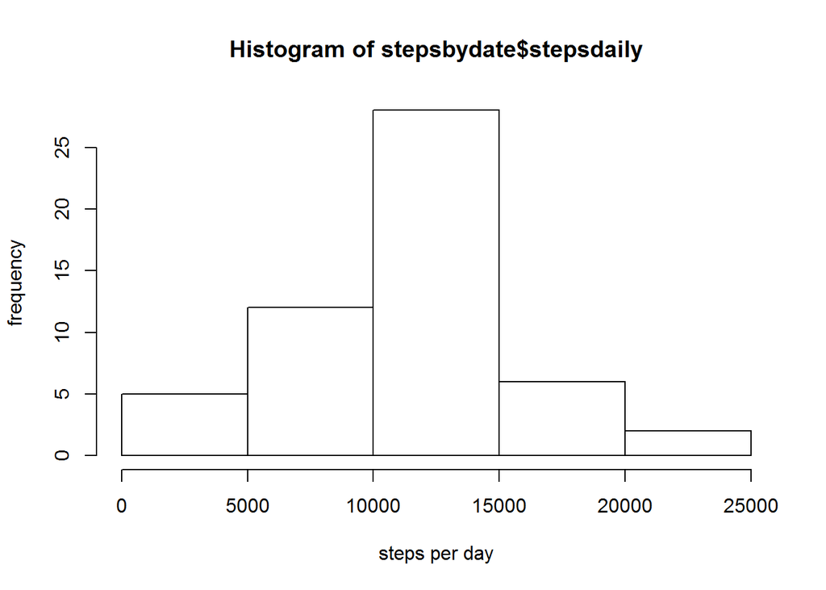

Calculate and report the mean and median of the total number of steps taken per day.

```r
mean_steps <- mean(stepsbydate$stepsdaily, na.rm = TRUE)
```

Mean =

```
## [1] 10766.19
```

```r
median_steps <- median(stepsbydate$stepsdaily, na.rm = TRUE)
```

Median =

```
## [1] 10765
```

## What is the average daily activity pattern?

Make a time series plot (i.e. type = “l”) of the 5-minute interval (x-axis) and the average number of steps taken, averaged across all days (y-axis). Use dplyr package to calculate the mean per 5 minute interval and plot it.

```r
stepsGroupedByInterval <- data %>%
  filter(!is.na(steps)) %>%
  group_by(interval) %>%
  summarize(stepsByInterval = mean(steps))
```

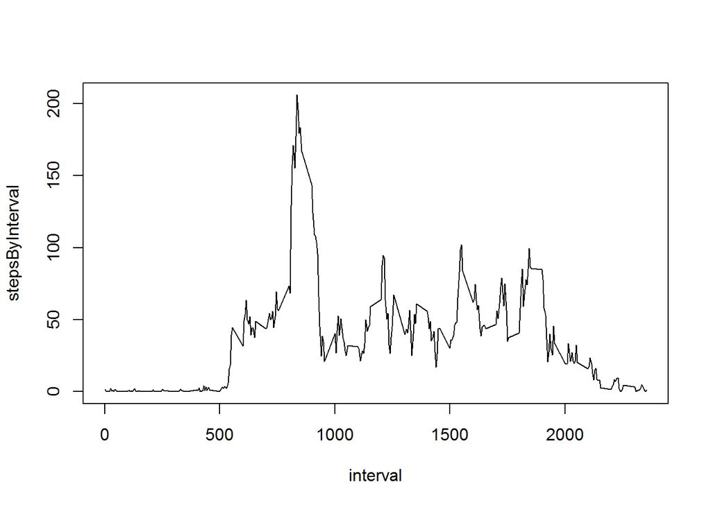

Which 5-minute interval, on average across all the days in the dataset, contains the maximum number of steps?.

```r
highInterval <- filter(stepsGroupedByInterval, stepsByInterval == max(stepsGroupedByInterval$stepsByInterval))
```

```
## Source: local data frame [1 x 2]
##
##   interval stepsByInterval
##      (int)           (dbl)
## 1      835        206.1698
```

## Imputing missing values

Fill in the NA values with the mean values for that time interval from the data set that contains the mean steps by interval that was calculated earlier.

```r
data_full <- data

for(i in 1:nrow(data_full)){
  if(is.na(data_full[i,1])){
    data_full[i,1] <- filter(stepsGroupedByInterval, interval == data_full[i,3])$stepsByInterval
  }
}
```

Group the filled in data set by date using the dplyr package

```r
stepsFullByDate <- data_full %>%
  filter(!is.na(steps)) %>%
  group_by(date) %>%
  summarize(stepsdaily = sum(steps))
```

Make a histogram of the total number of steps taken each day.

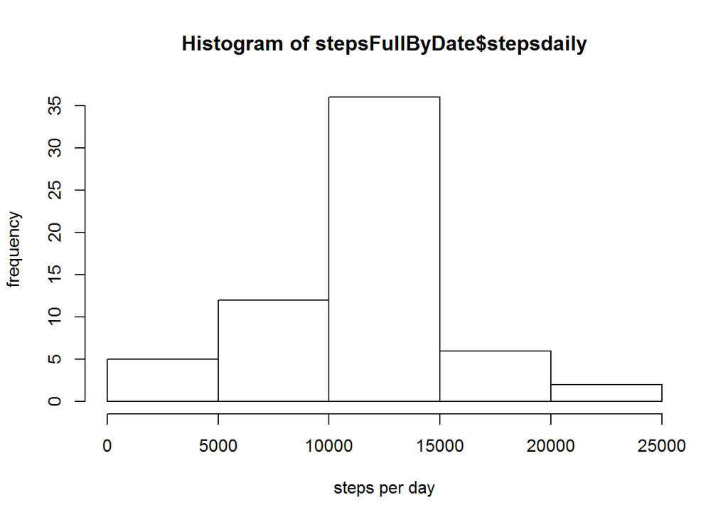

Calculate and report the mean and median of the total number of steps taken per day.

```r
mean_steps_full <- mean(stepsFullByDate$stepsdaily, na.rm = TRUE)
```

Mean =

```
## [1] 10766.19
```

```r
median_steps_full <- median(stepsFullByDate$stepsdaily, na.rm = TRUE)
```

Median =

```
## [1] 10766.19
```

## Are there differences in activity patterns between weekdays and weekends?

Create a new factor variable in the dataset with two levels - “weekday” and “weekend” indicating whether a given date is a weekday or weekend day.

```r
data_full <- mutate(data_full, weektype = ifelse(weekdays(data_full$date) == "Saturday" | weekdays(data_full$date) == "Sunday", "weekend", "weekday"))
data_full$weektype <- as.factor(data_full$weektype)
```

Use the dplyr package to group and sort by the interval and wekktype filter the weekday and weekend data into separate data sets and select only the interval and steps.

```r
full_data_by_interval_weektype <- data_full %>%
  group_by(interval, weektype) %>%
  summarize(stepsByInterval = mean(steps))


dailyact_weekday <- full_data_by_interval_weektype %>%
  filter(weektype == "weekday") %>%
  select(interval, stepsByInterval)



dailyact_weekend <- full_data_by_interval_weektype %>%
  filter(weektype == "weekend") %>%
  select(interval, stepsByInterval)
```

Plot the data for the weekday and the weekend and compare the average steps.

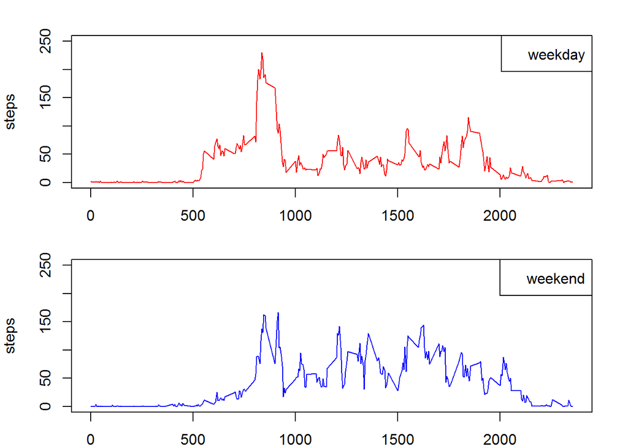